# WineQualityReds

#### 1.数据说明

1. Title: Wine Quality
2. Sources > Created by: Paulo Cortez (Univ. Minho), Antonio Cerdeira, Fernando Almeida, Telmo Matos and Jose Reis (CVRVV) @ 2009
3. Past Usage:

P. Cortez, A. Cerdeira, F. Almeida, T. Matos and J. Reis. Modeling wine preferences by data mining from physicochemical properties. In Decision Support Systems, Elsevier, 47(4):547-553. ISSN: 0167-9236.

In the above reference, two datasets were created, using red and white wine samples. The inputs include objective tests (e.g. PH values) and the output is based on sensory data (median of at least 3 evaluations made by wine experts). Each expert graded the wine quality between 0 (very bad) and 10 (very excellent). Several data mining methods were applied to model these datasets under a regression approach. The support vector machine model achieved the best results. Several metrics were computed: MAD, confusion matrix for a fixed error tolerance (T), etc. Also, we plot the relative importances of the input variables (as measured by a sensitivity analysis procedure).

4. Relevant Information:

The two datasets are related to red and white variants of the Portuguese “Vinho Verde” wine. For more details, consult: http://www.vinhoverde.pt/en/ or the reference [Cortez et al., 2009]. Due to privacy and logistic issues, only physicochemical (inputs) and sensory (the output) variables are available (e.g. there is no data about grape types, wine brand, wine selling price, etc.).

These datasets can be viewed as classification or regression tasks. The classes are ordered and not balanced (e.g. there are munch more normal wines than excellent or poor ones). Outlier detection algorithms could be used to detect the few excellent or poor wines. Also, we are not sure if all input variables are relevant. So it could be interesting to test feature selection methods.

5. Number of Instances: red wine - 1599; white wine - 4898.
6. Number of Attributes: 11 + output attribute

Note: several of the attributes may be correlated, thus it makes sense to apply some sort of feature selection.

7. Attribute information:

For more information, read [Cortez et al., 2009].

Input variables (based on physicochemical tests): 1 - fixed acidity (tartaric acid - g / dm^3) 2 - volatile acidity (acetic acid - g / dm^3) 3 - citric acid (g / dm^3) 4 - residual sugar (g / dm^3) 5 - chlorides (sodium chloride - g / dm^3 6 - free sulfur dioxide (mg / dm^3) 7 - total sulfur dioxide (mg / dm^3) 8 - density (g / cm^3) 9 - pH 10 - sulphates (potassium sulphate - g / dm3) 11 - alcohol (% by volume) Output variable (based on sensory data): 12 - quality (score between 0 and 10)

8. Missing Attribute Values: None
9. Description of attributes:
> 1. fixed acidity: most acids involved with wine or fixed or nonvolatile (do not evaporate readily)
> 2. volatile acidity: the amount of acetic acid in wine, which at too high of levels can lead to an unpleasant, vinegar taste
> 3. citric acid: found in small quantities, citric acid can add ‘freshness’ and flavor to wines
> 4. residual sugar: the amount of sugar remaining after fermentation stops, it’s rare to find wines with less than 1 gram/liter and wines with greater than 45 grams/liter are considered sweet
> 5. chlorides: the amount of salt in the wine
> 6. free sulfur dioxide: the free form of SO2 exists in equilibrium between molecular SO2 (as a dissolved gas) and bisulfite ion; it prevents microbial growth and the oxidation of wine
> 7. total sulfur dioxide: amount of free and bound forms of S02; in low concentrations, SO2 is mostly undetectable in wine, but at free SO2 concentrations over 50 ppm, SO2 becomes evident in the nose and taste of wine
> 8. density: the density of water is close to that of water depending on the percent alcohol and sugar content
> 9. pH: describes how acidic or basic a wine is on a scale from 0 (very acidic) to 14 (very basic); most wines are between 3-4 on the pH scale
> 10. sulphates: a wine additive which can contribute to sulfur dioxide gas (S02) levels, wich acts as an antimicrobial and antioxidant
> 11. alcohol: the percent alcohol content of the wine Output variable (based on sensory data):
> 12. quality (score between 0 and 10)

#### 2.Input DATA

```r
library(readr)
df <- read_csv("~/Desktop/P4/wineQualityReds.csv")
```

#### 3.DATA View

```r
head(df)
```

```
## # A tibble: 6 × 12
##   fixed.acidity volatile.acidity citric.acid residual.sugar chlorides
##           <dbl>            <dbl>       <dbl>          <dbl>     <dbl>
## 1           7.4             0.70        0.00            1.9     0.076
## 2           7.8             0.88        0.00            2.6     0.098
## 3           7.8             0.76        0.04            2.3     0.092
## 4          11.2             0.28        0.56            1.9     0.075
## 5           7.4             0.70        0.00            1.9     0.076
## 6           7.4             0.66        0.00            1.8     0.075
## # ... with 7 more variables: free.sulfur.dioxide <dbl>,
## #   total.sulfur.dioxide <int>, density <dbl>, pH <dbl>, sulphates <dbl>,
## #   alcohol <dbl>, quality <int>
```

```r
nrow(df)
```

```
## [1] 1599
```

```r
ncol(df)
```

```
## [1] 12
```

```r
names(df)
```

```
##  [1] "fixed.acidity"        "volatile.acidity"     "citric.acid"
##  [4] "residual.sugar"       "chlorides"            "free.sulfur.dioxide"
##  [7] "total.sulfur.dioxide" "density"              "pH"
## [10] "sulphates"            "alcohol"              "quality"
```

```r
summary(df)
```

```
##  fixed.acidity   volatile.acidity  citric.acid    residual.sugar
##  Min.   : 4.60   Min.   :0.1200   Min.   :0.000   Min.   : 0.900
##  1st Qu.: 7.10   1st Qu.:0.3900   1st Qu.:0.090   1st Qu.: 1.900
##  Median : 7.90   Median :0.5200   Median :0.260   Median : 2.200
##  Mean   : 8.32   Mean   :0.5278   Mean   :0.271   Mean   : 2.539
##  3rd Qu.: 9.20   3rd Qu.:0.6400   3rd Qu.:0.420   3rd Qu.: 2.600
##  Max.   :15.90   Max.   :1.5800   Max.   :1.000   Max.   :15.500
##
##    chlorides       free.sulfur.dioxide total.sulfur.dioxide
##  Min.   :0.01200   Min.   : 1.00       Min.   :  6.00
##  1st Qu.:0.07000   1st Qu.: 7.00       1st Qu.: 22.00
##  Median :0.07900   Median :14.00       Median : 38.00
##  Mean   :0.08747   Mean   :15.87       Mean   : 46.43
##  3rd Qu.:0.09000   3rd Qu.:21.00       3rd Qu.: 62.00
##  Max.   :0.61100   Max.   :72.00       Max.   :289.00
##                                        NA's   :2
##     density             pH          sulphates         alcohol
##  Min.   :0.9901   Min.   :2.740   Min.   :0.3300   Min.   : 8.40
##  1st Qu.:0.9956   1st Qu.:3.210   1st Qu.:0.5500   1st Qu.: 9.50
##  Median :0.9968   Median :3.310   Median :0.6200   Median :10.20
##  Mean   :0.9967   Mean   :3.311   Mean   :0.6581   Mean   :10.42
##  3rd Qu.:0.9978   3rd Qu.:3.400   3rd Qu.:0.7300   3rd Qu.:11.10
##  Max.   :1.0037   Max.   :4.010   Max.   :2.0000   Max.   :14.90
##
##     quality
##  Min.   :3.000
##  1st Qu.:5.000
##  Median :6.000
##  Mean   :5.636
##  3rd Qu.:6.000
##  Max.   :8.000
##
```

##### 3.1 Observe the missing values

```r
library("VIM")
```

[figure not shown]

[output not shown]

```r
matrixplot(df)
```

```r
df=na.omit(df)
```

缺失值只有两个，做删除处理

#### 4.初步观察数据

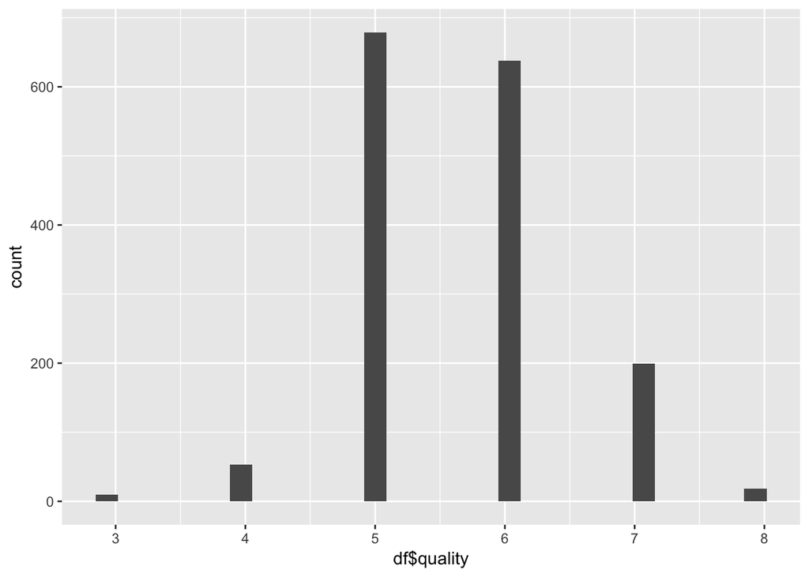

```r
library(ggplot2)
ggplot(df,aes(df$quality))+geom_histogram()
```

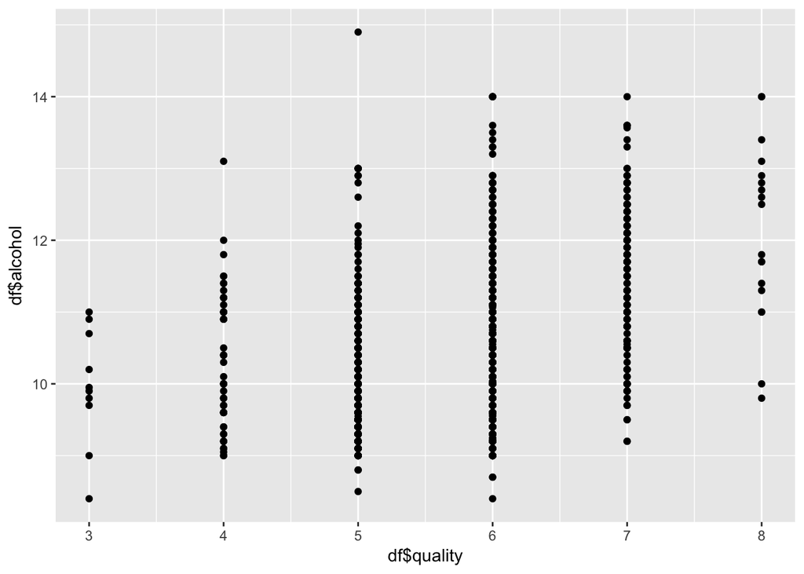

```r
ggplot(df,aes(df$quality,df$alcohol))+geom_point()
```

多数评分在5，6分之间

#### 5.相关性检查，共性因子检测

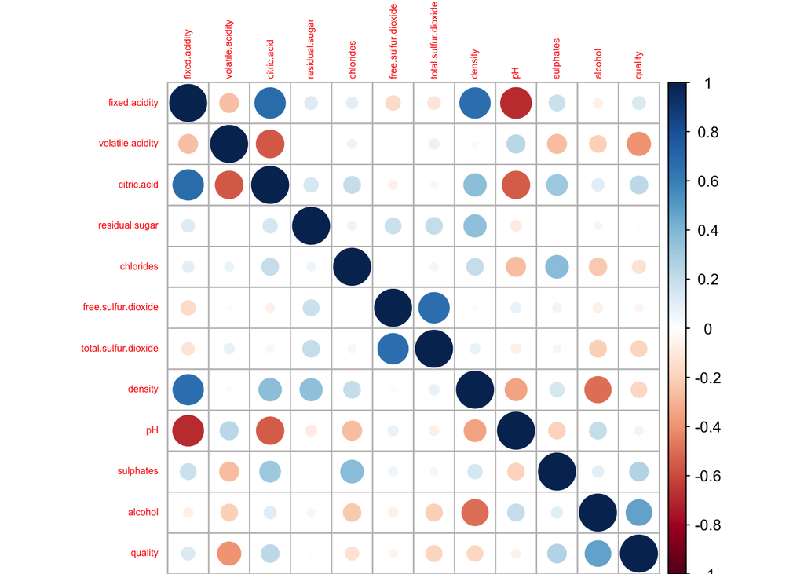

```r
require(corrplot)
#correlation analysis
cor1<-cor(df)
corrplot(cor1,tl.cex = 0.5)
```

##### 5.1进一步分析

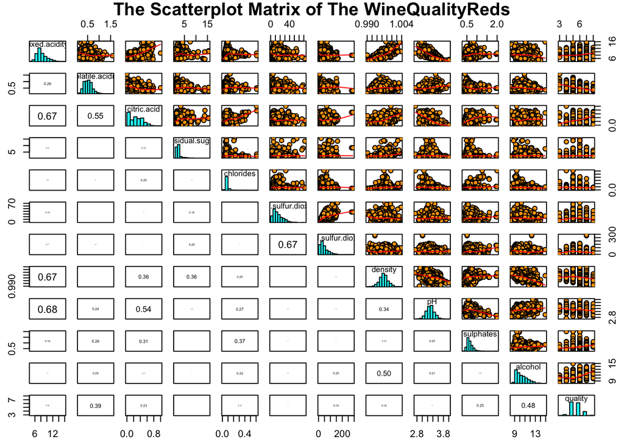

```r
panel.cor <- function(x, y, digits = 2, prefix = "", cex.cor, ...)
{
usr <- par("usr"); on.exit(par(usr))
par(usr = c(0, 1, 0, 1))
r <- abs(cor(x, y))
txt <- format(c(r, 0.123456789), digits = digits)[1]
txt <- paste0(prefix, txt)
if(missing(cex.cor)) cex.cor <- 0.8/strwidth(txt)
text(0.5, 0.5, txt, cex = cex.cor * r)
}
panel.hist <- function(x, ...)
{
usr <- par("usr"); on.exit(par(usr))
par(usr = c(usr[1:2], 0, 1.5) )
h <- hist(x, plot = FALSE)
breaks <- h$breaks; nB <- length(breaks)
y <- h$counts; y <- y/max(y)
rect(breaks[-nB], 0, breaks[-1], y, col = "cyan", ...)
}
pairs(df,
lower.panel=panel.cor,
upper.panel=panel.smooth,
diag.panel=panel.hist,
main = 'The Scatterplot Matrix of The WineQualityReds',
pch = 21,
bg = "orange",
line.main=1.5,
oma=c(2,2,3,2)
)
```

得出ph和fixed.acidity负相关性较高，density与fixed.acidity正相关性较高，在多元线性回归分析中除去fixed.acidity进行分析

#### 6.多元线性回归

```r
lm1<-lm(df$quality~df$volatile.acidity+df$citric.acid+df$residual.sugar+df$chlorides+df$free.sulfur.dioxide+df$total.sulfur.dioxide+df$density+df$pH+df$sulphates+df$alcohol,data=df)
lm1
```

```
##
## Call:
## lm(formula = df$quality ~ df$volatile.acidity + df$citric.acid +
##     df$residual.sugar + df$chlorides + df$free.sulfur.dioxide +
##     df$total.sulfur.dioxide + df$density + df$pH + df$sulphates +
##     df$alcohol, data = df)
##
## Coefficients:
##             (Intercept)      df$volatile.acidity           df$citric.acid
##                6.446317                -1.077605                -0.137540
##       df$residual.sugar             df$chlorides   df$free.sulfur.dioxide
##                0.010422                -1.966651                 0.004737
## df$total.sulfur.dioxide               df$density                    df$pH
##               -0.003454                -1.765481                -0.550900
##            df$sulphates               df$alcohol
##                0.897590                 0.289744
```

```r
summary(lm1)
```

```
##
## Call:
## lm(formula = df$quality ~ df$volatile.acidity + df$citric.acid +
##     df$residual.sugar + df$chlorides + df$free.sulfur.dioxide +
##     df$total.sulfur.dioxide + df$density + df$pH + df$sulphates +
##     df$alcohol, data = df)
##
## Residuals:
##      Min       1Q   Median       3Q      Max
## -2.65597 -0.36931 -0.04528  0.45558  2.03709
##
## Coefficients:
##                           Estimate Std. Error t value Pr(>|t|)
## (Intercept)              6.4463174 13.4540942   0.479   0.6319
## df$volatile.acidity     -1.0776052  0.1210153  -8.905  < 2e-16 ***
## df$citric.acid          -0.1375401  0.1389012  -0.990   0.3222
## df$residual.sugar        0.0104219  0.0135586   0.769   0.4422
## df$chlorides            -1.9666511  0.4079360  -4.821 1.57e-06 ***
## df$free.sulfur.dioxide   0.0047368  0.0021776   2.175   0.0298 *
## df$total.sulfur.dioxide -0.0034540  0.0007112  -4.857 1.31e-06 ***
## df$density              -1.7654813 13.4050455  -0.132   0.8952
## df$pH                   -0.5509000  0.1336397  -4.122 3.95e-05 ***
## df$sulphates             0.8975896  0.1131341   7.934 3.98e-15 ***
## df$alcohol               0.2897443  0.0222521  13.021  < 2e-16 ***
## ---
## Signif. codes:  0 '***' 0.001 '**' 0.01 '*' 0.05 '.' 0.1 ' ' 1
##
## Residual standard error: 0.6484 on 1586 degrees of freedom
## Multiple R-squared:  0.3598, Adjusted R-squared:  0.3558
## F-statistic: 89.13 on 10 and 1586 DF,  p-value: < 2.2e-16
```

影响一瓶红酒的品质的主要因素有：volatile.acidity ，chlorides ，free.sulfur.dioxide，total.sulfur.dioxide，pH ，sulphates ，alcohol。

#### 总结：影响一瓶红酒的品质的主要有volatile.acidity ，chlorides ，free.sulfur.dioxide，total.sulfur.dioxide，pH ，sulphates ，alcohol这些因素，但是由于本数据样本较小，且多数集中5，6级的评级，且分布较为平均，不是能很好的分析出影响一瓶好红酒有哪些因素。